# Mode Choice and Independent Travel

United States, 2017

Carole Voulgaris

2023-04-07

# Overview

This analysis seeks to answer the following questions of trips to school taken by children between the ages of 8 and 13 years old:

- What characteristics of trips, individuals, and households are associated with the likelihood:
  - that a journey to school will be independent (alone or without a household adult)?
  - that a journey to school will be by an active mode (cycling or walking)?
- Do households select their children’s travel mode:
  - after deciding whether their child will travel independently,
  - before deciding whether their child will travel independently, or
  - simultaneously with the decision on independent travel?

We are drafting the paper in Overleaf here: https://www.overleaf.com/read/hxhgmcxbmpwd

The project GitHub repo (including this RMarkdown file) is here: https://github.com/c-voulgaris/active-independent-travel

## Libraries

This analysis uses the following libraries

```r
library(here)
library(tidyverse)
library(mlogit)
library(downloader)
library(patchwork)
library(knitr)

here("code",
     "mlogit_helpers.R") |>
  source()
```

# Data

This analysis uses data from the 2017 National Household Travel Survey. This code will download the data to a local folder if you don’t have it already.

```r
url <- "https://nhts.ornl.gov/assets/2016/download/csv.zip"
nhts_zipped <- here("nhts.zip")
nhts_dir <- here("nhts")

download(url, nhts_zipped, mode="wb")
unzip(nhts_zipped, exdir = nhts_dir)
```

Read the data in and set up unique IDs for each trip and each person.

```r
trips <- here("nhts", "trippub.csv") |>
  read_csv(show_col_types = FALSE)

people <- here("nhts", "perpub.csv") |>
  read_csv(show_col_types = FALSE) |>
  mutate(person_hh = paste(PERSONID, HOUSEID, sep = "-"))

hhs <- here("nhts", "hhpub.csv") |>
  read_csv(show_col_types = FALSE)
```

## Filter to short trips to school

I’ll filter the data to only include trips that meet the following criteria:

- Trips that end (but do not begin) at school
- Trips by children between the ages of 8 and 13
- Trips that end before 10am
- The first such trip of the day by any person
- Trip is shorter than 1.25 miles (2 km)

Also creating a separate dataframe that includes all trips by the household of the the trips in the study sample.

If there are unlinked trips (e.g. a trip purpose is to transfer to/from another mode), we link them together and assign the whole thing the mode of the longest segment.

```r
school_trip_hhs <- trips |>
  mutate(include_trip = (WHYTO == "08" &
                           WHYFROM != "08" &
                         R_AGE > 7 &
                         R_AGE < 14 &
                         as.numeric(ENDTIME) < 1000 &
                         TRPMILES > 0)) |>
  group_by(HOUSEID) |>
  mutate(include_hh = sum(include_trip) > 0) |>
  filter(include_hh) |>
    mutate(WHYTO = case_when(WHYTO == "08" ~ "school",
                           WHYTO == "07" ~ "transfer",
                           WHYTO == "01" ~ "home",
                           WHYTO == "02" ~ "wfh",
                           WHYTO == "03" ~ "work",
                           WHYTO == "06" ~ "chauffer",
                           WHYTO == "11" ~ "shopping",
                           WHYTO == "19" ~ "community",
                           TRUE ~ WHYTO),
         WHYFROM = case_when(WHYFROM == "08" ~ "school",
                           WHYFROM == "07" ~ "transfer",
                           WHYFROM == "01" ~ "home",
                           WHYFROM == "02" ~ "wfh",
                           WHYFROM == "03" ~ "work",
                           WHYFROM == "06" ~ "chauffer",
                           WHYFROM == "11" ~ "shopping",
                           WHYFROM == "19" ~ "community",
                           TRUE ~ WHYFROM)) |>
  mutate(mode = case_when(TRPTRANS == "10" ~ "school bus",
                              TRPTRANS == "03" ~ "car",
                              TRPTRANS == "04" ~ "car",
                              TRPTRANS == "05" ~ "car",
                              TRPTRANS == "06" ~ "car",
                              TRPTRANS == "01" ~ "walk",
                              TRPTRANS == "02" ~ "bike",
                              TRPTRANS == "11" ~ "transit",
                              TRPTRANS == "12" ~ "transit",
                              TRPTRANS == "13" ~ "transit",
                              TRPTRANS == "14" ~ "transit",
                              TRPTRANS == "15" ~ "transit",
                              TRPTRANS == "16" ~ "transit",
                          TRUE ~ TRPTRANS)) |>
  mutate(TDTRPNUM = ifelse(WHYFROM == "transfer",
                           paste0("0", as.numeric(TDTRPNUM) - 1),
                           TDTRPNUM)) |>
  mutate(trip_person_hh = paste(TDTRPNUM, PERSONID, HOUSEID, sep = "-")) |>
  mutate(person_hh = paste(PERSONID, HOUSEID, sep = "-")) |>
  group_by(trip_person_hh) |>
  mutate(longest_seg = TRPMILES == max(TRPMILES)) |>
  mutate(mode = ifelse(longest_seg, mode, "zz")) |>
  mutate(NUMONTRP = ifelse(longest_seg, NUMONTRP, -1)) |>
  mutate(ONTD_P1 = ifelse(longest_seg, as.numeric(ONTD_P1), -1),
         ONTD_P2 = ifelse(longest_seg, as.numeric(ONTD_P2), -1),
         ONTD_P3 = ifelse(longest_seg, as.numeric(ONTD_P3), -1),
         ONTD_P4 = ifelse(longest_seg, as.numeric(ONTD_P4), -1),
         ONTD_P5 = ifelse(longest_seg, as.numeric(ONTD_P5), -1),
         ONTD_P6 = ifelse(longest_seg, as.numeric(ONTD_P6), -1),
         ONTD_P7 = ifelse(longest_seg, as.numeric(ONTD_P7), -1),
         ONTD_P8 = ifelse(longest_seg, as.numeric(ONTD_P8), -1),
         ONTD_P9 = ifelse(longest_seg, as.numeric(ONTD_P9), -1),
         ONTD_P10 = ifelse(longest_seg, as.numeric(ONTD_P10), -1),
         ONTD_P11 = ifelse(longest_seg, as.numeric(ONTD_P11), -1),
         ONTD_P12 = ifelse(longest_seg, as.numeric(ONTD_P12), -1),
         ONTD_P13 = ifelse(longest_seg, as.numeric(ONTD_P13), -1)) |>
  summarise(person_hh = first(person_hh),
            HOUSEID = first(HOUSEID),
            WHYFROM = first(WHYFROM),
            WHYTO = last(WHYTO),
            mode = min(mode),
            NUMONTRP = max(NUMONTRP),
            R_AGE = first(R_AGE),
            ENDTIME = last(ENDTIME),
            include_trip = max(include_trip),
            ONTD_P1 = max(ONTD_P1),
            ONTD_P2 = max(ONTD_P2),
            ONTD_P3 = max(ONTD_P3),
            ONTD_P4 = max(ONTD_P4),
            ONTD_P5 = max(ONTD_P5),
            ONTD_P6 = max(ONTD_P6),
            ONTD_P7 = max(ONTD_P7),
            ONTD_P8 = max(ONTD_P8),
            ONTD_P9 = max(ONTD_P9),
            ONTD_P10 = max(ONTD_P10),
            ONTD_P11 = max(ONTD_P11),
            ONTD_P12 = max(ONTD_P12),
            ONTD_P13 = max(ONTD_P13),
            HHVEHCNT = first(HHVEHCNT),
            DRVRCNT = first(DRVRCNT),
            HHFAMINC = first(HHFAMINC),
            R_SEX_IMP = first(R_SEX_IMP),
            TRPMILES = sum(TRPMILES),
            DBPPOPDN = last(DBPPOPDN),
            OBPPOPDN = first(OBPPOPDN)) |>
group_by(person_hh) |>
  mutate(can_drive = DRVRCNT > 0 & HHVEHCNT > 0,
         can_sch_bus = sum(mode == "school bus") > 0) |>
  ungroup() |>
  filter(TRPMILES < 1.25)

school_trips <- school_trip_hhs |>
  filter(include_trip > 0) |>
  filter(!duplicated(person_hh))

sample <- tibble(Type = c("Number of trips",
                "Number of children",
                "Number of households"),
       `Sample size` = c(length(unique(school_trips$trip_person_hh)),
                         length(unique(school_trips$person_hh)),
                         length(unique(school_trips$HOUSEID))))

kable(sample)
```

| Type | Sample size |
| --- | --- |
| Number of trips | 2165 |
| Number of children | 2165 |
| Number of households | 1758 |

## Dependent variables: Trip mode and independence

Tabulate trips by mode:

```r
school_trips |>
  group_by(mode) |>
  summarise(`Trips in sample` = n()) |>
  kable()
```

| mode | Trips in sample |
| --- | --- |
| 08 | 2 |
| 97 | 11 |
| bike | 119 |
| car | 1228 |
| school bus | 286 |
| transit | 10 |
| walk | 509 |

Remove transit, motorcycle, and “other” trips. Each of the remaining modes (car, school bus, bike, walk) has at least 100 trips in the sample.

```r
school_trips <- school_trips |>
  filter(mode != "transit" &
           mode != "08" &
           mode != "97")

sample <- tibble(Type = c("Number of trips",
                "Number of children",
                "Number of households"),
       `Sample size` = c(length(unique(school_trips$trip_person_hh)),
                         length(unique(school_trips$person_hh)),
                         length(unique(school_trips$HOUSEID))))

kable(sample)
```

| Type | Sample size |
| --- | --- |
| Number of trips | 2142 |
| Number of children | 2142 |
| Number of households | 1740 |

We’ll create a trip-level variable indicating the independence of each trip:

- `alone`: The child was unaccompanied
- `hh_adlt`: The child traveled with a household adult
- `others`: The child was accompanied by a person other than a household adult, which might be:
  - Household children
  - Non-household children
  - Non-household adult(s)

```r
hh_ages <- people %>%
  select(HOUSEID, PERSONID, R_AGE) %>%
  pivot_wider(names_from = PERSONID,
              names_prefix = "age_",
              values_from = R_AGE)

school_trips <- school_trips |>
  left_join(hh_ages) %>%
  mutate(alone = NUMONTRP == 1,
         with_hh_adult =
           (ONTD_P1 == 1 & age_01 > 17) |
           (ONTD_P2 == 1 & age_02 > 17) |
           (ONTD_P3 == 1 & age_03 > 17) |
           (ONTD_P4 == 1 & age_04 > 17) |
           (ONTD_P5 == 1 & age_05 > 17) |
           (ONTD_P6 == 1 & age_06 > 17) |
           (ONTD_P7 == 1 & age_07 > 17) |
           (ONTD_P8 == 1 & age_08 > 17) |
           (ONTD_P9 == 1 & age_09 > 17) |
           (ONTD_P10 == 1 & age_10 > 17) |
           (ONTD_P11 == 1 & age_11 > 17) |
           (ONTD_P12 == 1 & age_12 > 17) |
           (ONTD_P13 == 1 & age_13 > 17)) |>
  mutate(independence = case_when(mode == "school bus" ~ "school bus",
                                  with_hh_adult ~ "hh_adlt",
                                  alone ~ "alone",
                                  TRUE ~ "others")) |>
  mutate(independence = fct_infreq(independence))
```

Here is an unweighted cross-tabulation of mode and independence. We’re not tracking independence for school bus trips because I’m honestly not convinced survey respondents were counting the number of people on the trip in any kind of consistent way.

```r
table(school_trips$mode, school_trips$independence) |>
  kable()
```

|  | hh_adlt | school bus | others | alone |
| --- | --- | --- | --- | --- |
| bike | 25 | 0 | 27 | 67 |
| car | 1127 | 0 | 86 | 15 |
| school bus | 0 | 286 | 0 | 0 |
| walk | 185 | 0 | 163 | 161 |

15 out of 2142 trips (about 0.7 percent) are shown as children between 8 and 13 driving alone, which is odd since children younger than 14 are not legally permitted to operate a motor vehicle in any state in the United States (in six states, 14-year-olds can get a learner’s permit which allows them to drive with a licensed driver in the car). This is likely a coding error, so we will filter these trips out and create a combined variable to indicate both mode and independence.

```r
school_trips <- school_trips |>
  mutate(mode_ind = paste(mode, independence, sep = "-")) |>
  mutate(mode_ind = ifelse(substr(mode_ind, 1, 3) == "sch",
                           "school-bus", mode_ind)) |>
  filter(mode_ind != "car-alone")

sample <- tibble(Type = c("Number of trips",
                "Number of children",
                "Number of households"),
       `Sample size` = c(length(unique(school_trips$trip_person_hh)),
                         length(unique(school_trips$person_hh)),
                         length(unique(school_trips$HOUSEID))))

kable(sample)
```

| Type | Sample size |
| --- | --- |
| Number of trips | 2127 |
| Number of children | 2127 |
| Number of households | 1725 |

This leaves us with 2127 trips by 2127 children in 1725 households.

```r
school_trips |>
  group_by(mode_ind) |>
  summarise(`Trips in sample` = n()) |>
  kable()
```

| mode_ind | Trips in sample |
| --- | --- |
| bike-alone | 67 |
| bike-hh_adlt | 25 |
| bike-others | 27 |
| car-hh_adlt | 1127 |
| car-others | 86 |
| school-bus | 286 |
| walk-alone | 161 |
| walk-hh_adlt | 185 |
| walk-others | 163 |

## Independent variables

We’ll include the following independent variables in our analysis:

Household characteristics:

- Number of vehicles per driver
- Household income
- Number of household adults
- Presence of a non-working adult

Person characteristics:

- Gender
- Age
- Presence of a younger sibling
- Presence of an older sibling

Trip characteristics: * Distance * Density

### Vehicle Availability

We’ll calculate the ratio of vehicles per driver. Households with zero drivers are assigned a value of zero.

```r
school_trips <- school_trips |>
  mutate(veh_per_driver = ifelse(DRVRCNT > 0, HHVEHCNT/DRVRCNT, 0))
```

### Household income

Household income is reported in one of 11 income categories. We convert this to a continuous variable by assigning households in each category the mid-point value of that category. The highest income category is for incomes greater than $200,000 per year. We assign an income of $250,000 to that category.

31 children in 26 households for which no income is reported are excluded from the analysis.

```r
school_trips <- school_trips |>
  mutate(income_k = case_when(HHFAMINC == "01" ~ 5,
                              HHFAMINC == "02" ~ 12.5,
                              HHFAMINC == "03" ~ 20,
                              HHFAMINC == "04" ~ 30,
                              HHFAMINC == "05" ~ 42.5,
                              HHFAMINC == "06" ~ 62.5,
                              HHFAMINC == "07" ~ 87.5,
                              HHFAMINC == "08" ~ 112.5,
                              HHFAMINC == "09" ~ 137.5,
                              HHFAMINC == "10" ~ 175,
                              HHFAMINC == "11" ~ 250,
                              TRUE ~ -9)) |>
  filter(income_k > 0)

sample <- tibble(Type = c("Number of trips",
                "Number of children",
                "Number of households"),
       `Sample size` = c(length(unique(school_trips$trip_person_hh)),
                         length(unique(school_trips$person_hh)),
                         length(unique(school_trips$HOUSEID))))

kable(sample)
```

| Type | Sample size |
| --- | --- |
| Number of trips | 2096 |
| Number of children | 2096 |
| Number of households | 1699 |

This leaves us with a sample of 2096 trips by 2096 children in 1699 households.

### Gender

All survey respondents were coded as either male or female. We created a binary variable indicating whether or not the survey respondent was coded as female.

```r
school_trips <- school_trips |>
  mutate(female = R_SEX_IMP == "02")
```

### Age

Age is available directly from the survey data.

### Birth order

We’ll create two individual-level variables indicating whether each child has an older sibling and/or a younger sibling.

```r
birth_order <- people |>
  mutate(adult = R_AGE > 17,
         kid_age = ifelse(R_AGE < 18, R_AGE, -2),
         R_AGE = ifelse(R_AGE < 0, 999, R_AGE),
         non_worker_adlt = R_AGE > 17 & WORKER != "01") |>
  group_by(HOUSEID) |>
  mutate(n_adults = sum(adult),
         num_records = n(),
         non_work_adlts = sum(non_worker_adlt) > 0) |>
  mutate(youngest_kid = ifelse(num_records > HHSIZE, 1, min(R_AGE)),
         oldest_kid = max(kid_age),
         n_children = HHSIZE - n_adults) |>
  mutate(has_old_sib = n_children > 1 & R_AGE != oldest_kid,
         has_lil_sib = n_children > 1 & R_AGE != youngest_kid) |>
  mutate(person_hh = paste(PERSONID, HOUSEID, sep = "-")) |>
  ungroup() |>
  select(person_hh, WORKER, has_lil_sib, has_old_sib, n_adults, non_work_adlts)


school_trips <- school_trips |>
  left_join(birth_order)
```

### Distance

Trip distance is available directly from the survey. Trips with missing values for distance are excluded (1 trip).

```r
school_trips <- school_trips |>
  filter(TRPMILES > 0)

sample <- tibble(Type = c("Number of trips",
                "Number of children",
                "Number of households"),
       `Sample size` = c(length(unique(school_trips$trip_person_hh)),
                         length(unique(school_trips$person_hh)),
                         length(unique(school_trips$HOUSEID))))

kable(sample)
```

| Type | Sample size |
| --- | --- |
| Number of trips | 2095 |
| Number of children | 2095 |
| Number of households | 1698 |

### Density

We’ll create a variable to indicate the population density of the trips’ origin or destination census block group (whichever is higher).

We’ll filter 1 trip with missing density values for both trip ends.

```r
 school_trips <- school_trips |>
  mutate(max_od_dens = ifelse(DBPPOPDN > OBPPOPDN, DBPPOPDN, OBPPOPDN)) |>
  filter(max_od_dens > 0)

sample <- tibble(Type = c("Number of trips",
                "Number of children",
                "Number of households"),
       `Sample size` = c(length(unique(school_trips$trip_person_hh)),
                         length(unique(school_trips$person_hh)),
                         length(unique(school_trips$HOUSEID))))

kable(sample)
```

| Type | Sample size |
| --- | --- |
| Number of trips | 2094 |
| Number of children | 2094 |
| Number of households | 1697 |

## Mode availability

We do not have information on which modes were available for each trip.

We will assume that:

- Walking and biking are always available (this overestimates the availability of cycling, since not all households own a child-sized bike and not all children know how to ride a bike).
- Driving with a household adult is an option the household has at least one vehicle and at least one driver.
- Driving with others (e.g. a non-household adult) is always available
- School bus service is available for the journey to school if the child used for the the journey to or from school on the survey day.

```r
mode_avail <- tibble(mode = c("drive-hh-adlt",
                              "drive-others",
                              "bike",
                              "walk",
                              "school-bus"),
                     share_used = c((sum(school_trips$mode_ind ==
                                          "car-hh_adlt") / nrow(school_trips)),
                                    (sum(school_trips$mode_ind ==
                                          "car-others") / nrow(school_trips)),
                                    (sum(school_trips$mode == "bike") / nrow(school_trips)),
                                    (sum(school_trips$mode == "walk") / nrow(school_trips)),
                                    (sum(school_trips$mode ==
                                           "school bus") / nrow(school_trips))),
                     share_avail = c(sum(school_trips$can_drive) / nrow(school_trips),
                                     1, 1, 1,
                                     sum(school_trips$can_sch_bus) / nrow(school_trips)))

kable(mode_avail)
```

| mode | share_used | share_avail |
| --- | --- | --- |
| drive-hh-adlt | 0.5300860 | 0.9708691 |
| drive-others | 0.0410697 | 1.0000000 |
| bike | 0.0549188 | 1.0000000 |
| walk | 0.2397326 | 1.0000000 |
| school-bus | 0.1341929 | 0.2005731 |

Remove those eligible for school bus service from the sample (it’s too complicated to include them).

```r
school_trips <- school_trips |>
  filter(!can_sch_bus)

sample <- tibble(Type = c("Number of trips",
                "Number of children",
                "Number of households"),
       `Sample size` = c(length(unique(school_trips$trip_person_hh)),
                         length(unique(school_trips$person_hh)),
                         length(unique(school_trips$HOUSEID))))

kable(sample)
```

| Type | Sample size |
| --- | --- |
| Number of trips | 1674 |
| Number of children | 1674 |
| Number of households | 1364 |

```r
table(school_trips$mode, school_trips$independence) |>
  kable()
```

|  | hh_adlt | school bus | others | alone |
| --- | --- | --- | --- | --- |
| bike | 24 | 0 | 23 | 67 |
| car | 999 | 0 | 81 | 0 |
| walk | 172 | 0 | 153 | 155 |

# Summary statistics

```r
tibble(var = c("income_k",
               "veh_per_driver",
               "n_adults",
               "is_non_work_adlt",
               "Age",
               "female",
               "lil_sib",
               "big_sib",
               "distance",
               "density"),
       mean = c(mean(school_trips$income_k),
                mean(school_trips$veh_per_driver, na.rm = TRUE),
                mean(school_trips$n_adults),
                mean(school_trips$non_work_adlts),
                mean(school_trips$R_AGE),
                mean(school_trips$female),
                mean(school_trips$has_lil_sib),
                mean(school_trips$has_old_sib),
                mean(school_trips$TRPMILES),
                mean(school_trips$max_od_dens)),
       sd = c(sd(school_trips$income_k),
                sd(school_trips$veh_per_driver, na.rm = TRUE),
                sd(school_trips$n_adults),
                999,
                sd(school_trips$R_AGE),
                999,
                999,
                999,
                sd(school_trips$TRPMILES),
                sd(school_trips$max_od_dens))) |>
  kable()
```

| var | mean | sd |
| --- | --- | --- |
| income_k | 97.1580048 | 69.9183430 |
| veh_per_driver | 1.0954998 | 0.5213923 |
| n_adults | 2.0412186 | 0.6950237 |
| is_non_work_adlt | 0.4002389 | 999.0000000 |
| Age | 10.1517324 | 1.6425055 |
| female | 0.4778973 | 999.0000000 |
| lil_sib | 0.3960573 | 999.0000000 |
| big_sib | 0.4581840 | 999.0000000 |
| distance | 0.6839397 | 0.3010368 |
| density | 6409.5878136 | 5834.4514770 |

# Models

## Create dfidx dataframe

To run the mlogit function, we need to put our data into a dfidx structure, with a row for each alternative in each choice situation.

Now I’ll create one dataset that defines each mode as a separate alternative, one that defines each independence category as a separate alternative, and a third that defines each combination of mode and independence as a separate category.

```r
mode_dfidx <- fn_make_dfidx(school_trips,
                                   "trip_person_hh",
                                   "mode")

ind_dfidx <- fn_make_dfidx(school_trips,
                                   "trip_person_hh",
                                   "independence")

mode_ind_dfidx <- fn_make_dfidx(school_trips,
                                   "trip_person_hh",
                                   "mode_ind") |>
  filter(avail_choice != "car-others" | can_drive)
```

## Choice of mode

First will predict choice of mode.

```r
model_mode <- mlogit(choice ~ 0 |
                      log(income_k) +
                      veh_per_driver +
                      n_adults +
                      non_work_adlts +
                      R_AGE +
                      female +
                      has_lil_sib +
                      has_old_sib +
                      log(TRPMILES) +
                      log(max_od_dens) | 0,
                           mode_dfidx,
                           reflevel = "car")

summary(model_mode)
```

```
##
## Call:
## mlogit(formula = choice ~ 0 | log(income_k) + veh_per_driver +
##     n_adults + non_work_adlts + R_AGE + female + has_lil_sib +
##     has_old_sib + log(TRPMILES) + log(max_od_dens) | 0, data = mode_dfidx,
##     reflevel = "car", method = "nr")
##
## Frequencies of alternatives:choice
##     car    bike    walk
## 0.64516 0.06810 0.28674
##
## nr method
## 6 iterations, 0h:0m:0s
## g'(-H)^-1g = 0.000724
## successive function values within tolerance limits
##
## Coefficients :
##                           Estimate Std. Error  z-value  Pr(>|z|)
## (Intercept):bike        -4.6228406  1.2255720  -3.7720  0.000162 ***
## (Intercept):walk        -6.4678483  0.7942728  -8.1431 4.441e-16 ***
## log(income_k):bike       0.4383497  0.1307422   3.3528  0.000800 ***
## log(income_k):walk      -0.0233481  0.0709477  -0.3291  0.742088
## veh_per_driver:bike     -0.6460810  0.2766891  -2.3350  0.019541 *
## veh_per_driver:walk     -0.4956326  0.1517355  -3.2664  0.001089 **
## n_adults:bike           -0.0029359  0.1747252  -0.0168  0.986594
## n_adults:walk            0.1194855  0.0926861   1.2891  0.197349
## non_work_adltsTRUE:bike -0.1727301  0.2302955  -0.7500  0.453233
## non_work_adltsTRUE:walk -0.1463927  0.1413229  -1.0359  0.300261
## R_AGE:bike               0.1478289  0.0613153   2.4110  0.015910 *
## R_AGE:walk               0.1927491  0.0396008   4.8673 1.131e-06 ***
## femaleTRUE:bike         -1.0193314  0.2189783  -4.6549 3.241e-06 ***
## femaleTRUE:walk         -0.3376607  0.1258103  -2.6839  0.007277 **
## has_lil_sibTRUE:bike    -0.3578323  0.2216223  -1.6146  0.106396
## has_lil_sibTRUE:walk     0.1495158  0.1327690   1.1261  0.260109
## has_old_sibTRUE:bike    -0.0713141  0.2107429  -0.3384  0.735066
## has_old_sibTRUE:walk     0.1810664  0.1298239   1.3947  0.163104
## log(TRPMILES):bike       0.0660589  0.2400585   0.2752  0.783179
## log(TRPMILES):walk      -1.9634426  0.1293291 -15.1817 < 2.2e-16 ***
## log(max_od_dens):bike    0.0355193  0.0868452   0.4090  0.682543
## log(max_od_dens):walk    0.3579606  0.0584802   6.1211 9.296e-10 ***
## ---
## Signif. codes:  0 '***' 0.001 '**' 0.01 '*' 0.05 '.' 0.1 ' ' 1
##
## Log-Likelihood: -1158.5
## McFadden R^2:  0.16003
## Likelihood ratio test : chisq = 441.42 (p.value = < 2.22e-16)
```

Create data that varies one significance variable at a time.

```r
vary_inc_preds_mode <- fn_predictions(my_model = model_mode,
                                  to_vary = "income_k",
                                  max_sample = 2000) |>
  mutate(alternative = fct_relevel(alternative,
                                   "car",
                                   "bike",
                                   "walk"))

vary_veh_preds_mode <- fn_predictions(my_model = model_mode,
                                  to_vary = "veh_per_driver",
                                  max_sample = 2000) |>
  mutate(alternative = fct_relevel(alternative,
                                   "car",
                                   "bike",
                                   "walk"))

vary_age_preds_mode <- fn_predictions(my_model = model_mode,
                                  to_vary = "R_AGE",
                                  max_sample = 2000) |>
  mutate(alternative = fct_relevel(alternative,
                                   "car",
                                   "bike",
                                   "walk"))

vary_female_preds_mode <- fn_predictions(my_model = model_mode,
                                  to_vary = "female",
                                  max_sample = 2000) |>
  mutate(alternative = fct_relevel(alternative,
                                   "car",
                                   "bike",
                                   "walk"))
vary_dist_preds_mode <- fn_predictions(my_model = model_mode,
                                  to_vary = "TRPMILES",
                                  max_sample = 2000) |>
  mutate(alternative = fct_relevel(alternative,
                                   "car",
                                   "bike",
                                   "walk"))

vary_dens_preds_mode <- fn_predictions(my_model = model_mode,
                                  to_vary = "max_od_dens",
                                  max_sample = 2000) |>
  mutate(alternative = fct_relevel(alternative,
                                   "car",
                                   "bike",
                                   "walk"))
```

Make figures.

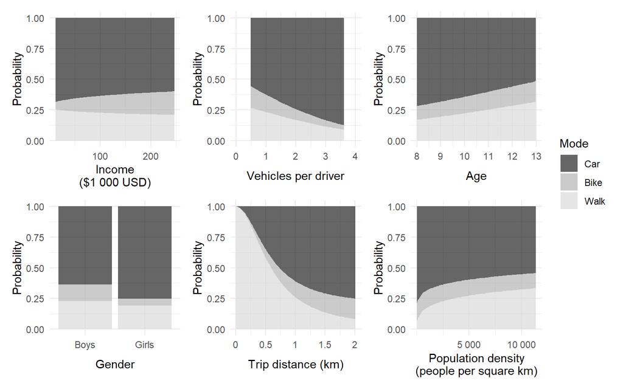

```r
inc_plot_mode <- ggplot(vary_inc_preds_mode) +
  geom_area(aes(x = income_k,
                y = probability,
                fill = alternative),
           alpha = 0.6) +
  scale_fill_manual(values = c("black",
                               "darkgray",
                               "lightgray"),
                      labels = c("Car",
                                 "Bike",
                                 "Walk"),
                     name = "Mode") +
  scale_x_continuous(name = "Income\n($1 000 USD)",
                     breaks = c(100, 200)) +
  scale_y_continuous(name = "Probability") +
  theme_minimal()

veh_plot_mode <- ggplot(vary_veh_preds_mode) +
  geom_area(aes(x = veh_per_driver,
                y = probability,
                fill = alternative),
           alpha = 0.6) +
  scale_fill_manual(values = c("black",
                               "darkgray",
                               "lightgray"),
                      labels = c("Car",
                                 "Bike",
                                 "Walk"),
                     name = "Mode") +
  scale_x_continuous(name = "Vehicles per driver",
                     limits = c(0, 4),
                     breaks = seq(0,4,by=1)) +
  scale_y_continuous(name = "Probability") +
  theme_minimal()

age_plot_mode <- ggplot(vary_age_preds_mode) +
  geom_area(aes(x = R_AGE,
                y = probability,
                fill = alternative),
           alpha = 0.6) +
  scale_fill_manual(values = c("black",
                               "darkgray",
                               "lightgray"),
                      labels = c("Car",
                                 "Bike",
                                 "Walk"),
                     name = "Mode") +
  scale_x_continuous(name = "Age") +
  scale_y_continuous(name = "Probability") +
  theme_minimal()

female_plot_mode <- ggplot(vary_female_preds_mode) +
  geom_bar(aes(x = female,
                y = probability,
                fill = alternative),
           stat = "identity",
           position = position_stack(),
           alpha = 0.6) +
  scale_fill_manual(values = c("black",
                               "darkgray",
                               "lightgray"),
                      labels = c("Car",
                                 "Bike",
                                 "Walk"),
                     name = "Mode") +
   scale_x_discrete(name = "Gender",
                      labels = c("Boys",
                                "Girls")) +
  scale_y_continuous(name = "Probability") +
  theme_minimal()

dist_plot_mode <- ggplot(vary_dist_preds_mode) +
  geom_area(aes(x = TRPMILES,
                y = probability,
                fill = alternative),
           alpha = 0.6) +
  scale_fill_manual(values = c("black",
                               "darkgray",
                               "lightgray"),
                      labels = c("Car",
                                 "Bike",
                                 "Walk"),
                     name = "Mode") +
  scale_x_continuous(name = "Trip distance (km)",
                     breaks = seq(0, 2, by=0.5)/1.609,
                     labels = seq(0, 2, by = 0.5)) +
  scale_y_continuous(name = "Probability") +
  theme_minimal()

dens_plot_mode <- ggplot(vary_dens_preds_mode) +
  geom_area(aes(x = max_od_dens,
                y = probability,
                fill = alternative),
           alpha = 0.6) +
  scale_fill_manual(values = c("black",
                               "darkgray",
                               "lightgray"),
                      labels = c("Car",
                                 "Bike",
                                 "Walk"),
                     name = "Mode") +
  scale_x_continuous(name = "Population density\n(people per square km)",
                     breaks = c(5000*2.59, 10000*2.59),
                     labels = c("5 000", "10 000")) +
  scale_y_continuous(name = "Probability") +
  theme_minimal()

inc_plot_mode + veh_plot_mode +
  age_plot_mode + female_plot_mode +
  dist_plot_mode + dens_plot_mode +
  plot_layout(guides = 'collect')
```

```r
ggsave(filename = "prob_plots_mode.png",
       width = 6.25, height = 4, units = "in", dpi = 300)
```

## Choice of independence

Predict choice of independence.

```r
model_ind <- mlogit(choice ~ 0 |
                       log(income_k) +
                       veh_per_driver +
                       n_adults +
                       non_work_adlts +
                       R_AGE +
                       female +
                       has_lil_sib +
                       has_old_sib +
                       log(TRPMILES) +
                       log(max_od_dens) | 0,
                           ind_dfidx,
                           reflevel = "hh_adlt")

summary(model_ind)
```

```
##
## Call:
## mlogit(formula = choice ~ 0 | log(income_k) + veh_per_driver +
##     n_adults + non_work_adlts + R_AGE + female + has_lil_sib +
##     has_old_sib + log(TRPMILES) + log(max_od_dens) | 0, data = ind_dfidx,
##     reflevel = "hh_adlt", method = "nr")
##
## Frequencies of alternatives:choice
## hh_adlt  others   alone
## 0.71386 0.15352 0.13262
##
## nr method
## 5 iterations, 0h:0m:0s
## g'(-H)^-1g = 0.00136
## successive function values within tolerance limits
##
## Coefficients :
##                              Estimate  Std. Error z-value  Pr(>|z|)
## (Intercept):others        -4.24645922  0.84758753 -5.0101 5.441e-07 ***
## (Intercept):alone         -7.75345161  0.95306988 -8.1352 4.441e-16 ***
## log(income_k):others      -0.09861477  0.07891588 -1.2496 0.2114388
## log(income_k):alone        0.00025211  0.08919767  0.0028 0.9977448
## veh_per_driver:others      0.05990412  0.12766490  0.4692 0.6389057
## veh_per_driver:alone       0.03684480  0.13995601  0.2633 0.7923503
## n_adults:others           -0.11652394  0.11849541 -0.9834 0.3254291
## n_adults:alone             0.09523397  0.12179915  0.7819 0.4342771
## non_work_adltsTRUE:others -0.52142562  0.16446208 -3.1705 0.0015218 **
## non_work_adltsTRUE:alone  -0.53009136  0.18674571 -2.8386 0.0045316 **
## R_AGE:others               0.21768464  0.04545809  4.7887 1.679e-06 ***
## R_AGE:alone                0.53971763  0.05140793 10.4987 < 2.2e-16 ***
## femaleTRUE:others         -0.41836961  0.14312391 -2.9231 0.0034653 **
## femaleTRUE:alone          -0.76136759  0.16355560 -4.6551 3.238e-06 ***
## has_lil_sibTRUE:others     0.37137595  0.14937036  2.4863 0.0129088 *
## has_lil_sibTRUE:alone     -0.69702612  0.17642631 -3.9508 7.789e-05 ***
## has_old_sibTRUE:others     0.49189876  0.14763168  3.3319 0.0008625 ***
## has_old_sibTRUE:alone      0.09743637  0.16403290  0.5940 0.5525087
## log(TRPMILES):others      -0.72653323  0.11833426 -6.1397 8.269e-10 ***
## log(TRPMILES):alone       -1.09136531  0.12912137 -8.4522 < 2.2e-16 ***
## log(max_od_dens):others    0.08191177  0.06034077  1.3575 0.1746267
## log(max_od_dens):alone     0.02997428  0.06393726  0.4688 0.6392071
## ---
## Signif. codes:  0 '***' 0.001 '**' 0.01 '*' 0.05 '.' 0.1 ' ' 1
##
## Log-Likelihood: -1193.9
## McFadden R^2:  0.10428
## Likelihood ratio test : chisq = 277.98 (p.value = < 2.22e-16)
```

Create data that varies one significance variable at a time.

```r
vary_non_work_preds_ind <- fn_predictions(my_model = model_ind,
                                  to_vary = "non_work_adlts",
                                  max_sample = 2000) |>
  mutate(alternative = fct_relevel(alternative,
                                   "hh_adlt",
                                   "others",
                                   "alone"))
vary_age_preds_ind <- fn_predictions(my_model = model_ind,
                                  to_vary = "R_AGE",
                                  max_sample = 2000) |>
  mutate(alternative = fct_relevel(alternative,
                                   "hh_adlt",
                                   "others",
                                   "alone"))

vary_female_preds_ind <- fn_predictions(my_model = model_ind,
                                  to_vary = "female",
                                  max_sample = 2000) |>
  mutate(alternative = fct_relevel(alternative,
                                   "hh_adlt",
                                   "others",
                                   "alone"))
vary_lil_sib_preds_ind <- fn_predictions(my_model = model_ind,
                                  to_vary = "has_lil_sib",
                                  max_sample = 2000) |>
  mutate(alternative = fct_relevel(alternative,
                                   "hh_adlt",
                                   "others",
                                   "alone"))
vary_old_sib_preds_ind <- fn_predictions(my_model = model_ind,
                                  to_vary = "has_old_sib",
                                  max_sample = 2000) |>
  mutate(alternative = fct_relevel(alternative,
                                   "hh_adlt",
                                   "others",
                                   "alone"))
vary_dist_preds_ind <- fn_predictions(my_model = model_ind,
                                  to_vary = "TRPMILES",
                                  max_sample = 2000) |>
  mutate(alternative = fct_relevel(alternative,
                                   "hh_adlt",
                                   "others",
                                   "alone"))
```

Make plots

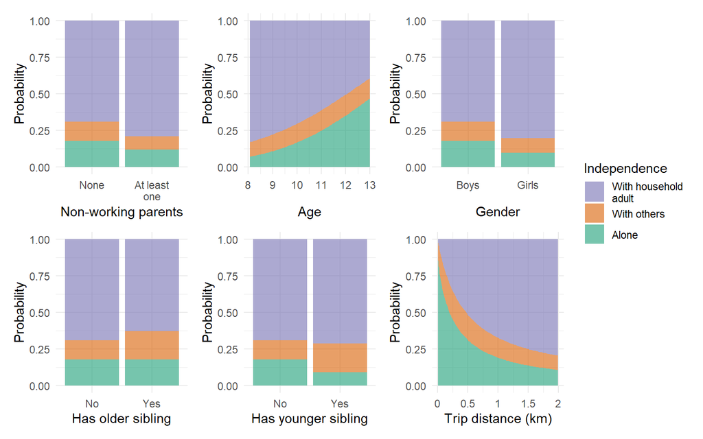

```r
non_work_plot_ind <- ggplot(vary_non_work_preds_ind) +
  geom_bar(aes(x = non_work_adlts,
                y = probability,
                fill = alternative),
           stat = "identity",
           position = position_stack(),
           alpha = 0.6) +
  scale_fill_manual(values = c("#7570B3",
                               "#D95F02",
                               "#1B9E77"),
                      labels = c("With household\nadult",
                                 "With others",
                                 "Alone"),
                     name = "Independence") +
   scale_x_discrete(name = "Non-working parents",
                      labels = c("None",
                                "At least\none")) +
  scale_y_continuous(name = "Probability") +
  theme_minimal()

age_plot_ind <- ggplot(vary_age_preds_ind) +
  geom_area(aes(x = R_AGE,
                y = probability,
                fill = alternative),
           alpha = 0.6) +
  scale_fill_manual(values = c("#7570B3",
                               "#D95F02",
                               "#1B9E77"),
                      labels = c("With household\nadult",
                                 "With others",
                                 "Alone"),
                     name = "Independence") +
  scale_x_continuous(name = "Age") +
  scale_y_continuous(name = "Probability") +
  theme_minimal()

female_plot_ind <- ggplot(vary_female_preds_ind) +
  geom_bar(aes(x = female,
                y = probability,
                fill = alternative),
           stat = "identity",
           position = position_stack(),
           alpha = 0.6) +
  scale_fill_manual(values = c("#7570B3",
                               "#D95F02",
                               "#1B9E77"),
                      labels = c("With household\nadult",
                                 "With others",
                                 "Alone"),
                     name = "Independence") +
   scale_x_discrete(name = "Gender",
                      labels = c("Boys",
                                "Girls")) +
  scale_y_continuous(name = "Probability") +
  theme_minimal()

old_sib_plot_ind <- ggplot(vary_old_sib_preds_ind) +
  geom_bar(aes(x = has_old_sib,
                y = probability,
                fill = alternative),
           stat = "identity",
           position = position_stack(),
           alpha = 0.6) +
  scale_fill_manual(values = c("#7570B3",
                               "#D95F02",
                               "#1B9E77"),
                      labels = c("With household\nadult",
                                 "With others",
                                 "Alone"),
                     name = "Independence") +
   scale_x_discrete(name = "Has older sibling",
                      labels = c("No", "Yes")) +
  scale_y_continuous(name = "Probability") +
  theme_minimal()

lil_sib_plot_ind <- ggplot(vary_lil_sib_preds_ind) +
  geom_bar(aes(x = has_lil_sib,
                y = probability,
                fill = alternative),
           stat = "identity",
           position = position_stack(),
           alpha = 0.6) +
  scale_fill_manual(values = c("#7570B3",
                               "#D95F02",
                               "#1B9E77"),
                      labels = c("With household\nadult",
                                 "With others",
                                 "Alone"),
                     name = "Independence") +
   scale_x_discrete(name = "Has younger sibling",
                      labels = c("No", "Yes")) +
  scale_y_continuous(name = "Probability") +
  theme_minimal()

dist_plot_ind <- ggplot(vary_dist_preds_ind) +
  geom_area(aes(x = TRPMILES,
                y = probability,
                fill = alternative),
           alpha = 0.6) +
  scale_fill_manual(values = c("#7570B3",
                               "#D95F02",
                               "#1B9E77"),
                      labels = c("With household\nadult",
                                 "With others",
                                 "Alone"),
                     name = "Independence") +
  scale_x_continuous(name = "Trip distance (km)",
                     breaks = seq(0, 2, by=0.5)/1.609,
                     labels = seq(0, 2, by = 0.5)) +
  scale_y_continuous(name = "Probability") +
  theme_minimal()

non_work_plot_ind + age_plot_ind +
  female_plot_ind + old_sib_plot_ind +
  lil_sib_plot_ind + dist_plot_ind +
  plot_layout(guides = 'collect')
```

```r
ggsave(filename = "prob_plots_ind.png",
       width = 6.5, height = 4, units = "in", dpi = 300)
```

## Combined choice of mode and independence

I’ll estimate three multinomial logistic regressions:

- One with options nested based on mode
- One with options nested based on independence
- One without nests

```r
model_mode_nests <- mlogit(choice ~ 0 |
                      log(income_k) +
                       veh_per_driver +
                       n_adults +
                       non_work_adlts +
                       R_AGE +
                       female +
                       has_lil_sib +
                       has_old_sib +
                       log(TRPMILES) +
                       log(max_od_dens) | 0,
                           mode_ind_dfidx,
                           reflevel = "car-hh_adlt",
                           nests = list(car = c("car-hh_adlt",
                                                  "car-others"),
                                        bike = c("bike-others",
                                                 "bike-hh_adlt",
                                                 "bike-alone"),
                                        walk = c("walk-hh_adlt",
                                                 "walk-alone",
                                                 "walk-others")))

summary(model_mode_nests)
```

```
##
## Call:
## mlogit(formula = choice ~ 0 | log(income_k) + veh_per_driver +
##     n_adults + non_work_adlts + R_AGE + female + has_lil_sib +
##     has_old_sib + log(TRPMILES) + log(max_od_dens) | 0, data = mode_ind_dfidx,
##     reflevel = "car-hh_adlt", nests = list(car = c("car-hh_adlt",
##         "car-others"), bike = c("bike-others", "bike-hh_adlt",
##         "bike-alone"), walk = c("walk-hh_adlt", "walk-alone",
##         "walk-others")))
##
## Frequencies of alternatives:choice
##  car-hh_adlt   bike-alone bike-hh_adlt  bike-others   car-others   walk-alone
##     0.596774     0.040024     0.014337     0.013740     0.048387     0.092593
## walk-hh_adlt  walk-others
##     0.102748     0.091398
##
## bfgs method
## 24 iterations, 0h:0m:8s
## g'(-H)^-1g =   8.3
## last step couldn't find higher value
##
## Coefficients :
##                                   Estimate Std. Error  z-value  Pr(>|z|)
## (Intercept):bike-alone          -3.4723728  1.6748897  -2.0732 0.0381541 *
## (Intercept):bike-hh_adlt        -2.3116632  2.3185455  -0.9970 0.3187492
## (Intercept):bike-others         -3.7758365  1.9655745  -1.9210 0.0547338 .
## (Intercept):car-others          -3.2382517  8.6421568  -0.3747 0.7078805
## (Intercept):walk-alone          -7.6130013  1.7156735  -4.4373 9.108e-06 ***
## (Intercept):walk-hh_adlt        -4.3980791  1.3288835  -3.3096 0.0009343 ***
## (Intercept):walk-others         -6.2958112  1.3769482  -4.5723 4.824e-06 ***
## log(income_k):bike-alone         0.3223456  0.1627887   1.9801 0.0476870 *
## log(income_k):bike-hh_adlt       0.3348308  0.1631904   2.0518 0.0401910 *
## log(income_k):bike-others        0.3346705  0.1718200   1.9478 0.0514392 .
## log(income_k):car-others        -1.2079736  0.9221071  -1.3100 0.1901910
## log(income_k):walk-alone        -0.1754547  0.1186963  -1.4782 0.1393589
## log(income_k):walk-hh_adlt      -0.0604809  0.1143280  -0.5290 0.5967967
## log(income_k):walk-others       -0.1431203  0.1092416  -1.3101 0.1901530
## veh_per_driver:bike-alone       -0.4541608  0.3100358  -1.4649 0.1429577
## veh_per_driver:bike-hh_adlt     -0.4479047  0.3096351  -1.4466 0.1480212
## veh_per_driver:bike-others      -0.5459090  0.3643287  -1.4984 0.1340301
```

[output cut: 54 more lines]

```
## log(max_od_dens):bike-hh_adlt   -0.0099320  0.1337343  -0.0743 0.9407983
## log(max_od_dens):bike-others    -0.0063386  0.1268600  -0.0500 0.9601503
## log(max_od_dens):car-others     -0.5719972  0.6375551  -0.8972 0.3696266
## log(max_od_dens):walk-alone      0.2151920  0.0954057   2.2555 0.0240991 *
## log(max_od_dens):walk-hh_adlt    0.4549005  0.1033560   4.4013 1.076e-05 ***
## log(max_od_dens):walk-others     0.3306807  0.0937104   3.5288 0.0004175 ***
## iv:car                           6.5771925  3.1850262   2.0650 0.0389196 *
## iv:bike                          0.0717460  0.1218215   0.5889 0.5558994
## iv:walk                          0.5974535  0.3079827   1.9399 0.0523927 .
## ---
## Signif. codes:  0 '***' 0.001 '**' 0.01 '*' 0.05 '.' 0.1 ' ' 1
##
## Log-Likelihood: -1924.4
## McFadden R^2:  0.16455
## Likelihood ratio test : chisq = 758.07 (p.value = < 2.22e-16)
```

Note that the logsum coefficient for car is greater than 1.0, so this model is not reasonable.

```r
model_ind_nests <- update(model_mode_nests,
                         nests = list(hh_adlt = c("bike-hh_adlt",
                                                  "car-hh_adlt",
                                                  "walk-hh_adlt"),
                                      others = c("bike-others",
                                                 "car-others",
                                                 "walk-others"),
                                      alone = c("bike-alone",
                                                "walk-alone")))

summary(model_ind_nests)
```

```
##
## Call:
## mlogit(formula = choice ~ 0 | log(income_k) + veh_per_driver +
##     n_adults + non_work_adlts + R_AGE + female + has_lil_sib +
##     has_old_sib + log(TRPMILES) + log(max_od_dens) | 0, data = mode_ind_dfidx,
##     reflevel = "car-hh_adlt", nests = list(hh_adlt = c("bike-hh_adlt",
##         "car-hh_adlt", "walk-hh_adlt"), others = c("bike-others",
##         "car-others", "walk-others"), alone = c("bike-alone",
##         "walk-alone")))
##
## Frequencies of alternatives:choice
##  car-hh_adlt   bike-alone bike-hh_adlt  bike-others   car-others   walk-alone
##     0.596774     0.040024     0.014337     0.013740     0.048387     0.092593
## walk-hh_adlt  walk-others
##     0.102748     0.091398
##
## bfgs method
## 12 iterations, 0h:0m:5s
## g'(-H)^-1g =   4.5
## last step couldn't find higher value
##
## Coefficients :
##                                   Estimate Std. Error z-value  Pr(>|z|)
## (Intercept):bike-alone          -7.6203771  1.1631782 -6.5513 5.702e-11 ***
## (Intercept):bike-hh_adlt         4.0251871  3.9433262  1.0208 0.3073685
## (Intercept):bike-others         -6.0858366  2.8605338 -2.1275 0.0333771 *
## (Intercept):car-others          -2.0287475  1.6894169 -1.2009 0.2298068
## (Intercept):walk-alone          -8.0924494  1.1346839 -7.1319 9.899e-13 ***
## (Intercept):walk-hh_adlt        -4.6113179  1.6998784 -2.7127 0.0066731 **
## (Intercept):walk-others         -6.3226127  1.5136391 -4.1771 2.953e-05 ***
## log(income_k):bike-alone         0.0411890  0.1299976  0.3168 0.7513620
## log(income_k):bike-hh_adlt       0.4178034  0.3054637  1.3678 0.1713848
## log(income_k):bike-others        0.2425357  0.3322508  0.7300 0.4654038
## log(income_k):car-others        -0.1539042  0.1208106 -1.2739 0.2026881
## log(income_k):walk-alone        -0.0208698  0.1020355 -0.2045 0.8379354
## log(income_k):walk-hh_adlt       0.0953977  0.1051914  0.9069 0.3644617
## log(income_k):walk-others       -0.0646546  0.0857525 -0.7540 0.4508690
## veh_per_driver:bike-alone       -0.1377103  0.1918567 -0.7178 0.4728950
## veh_per_driver:bike-hh_adlt     -0.7662515  0.5488567 -1.3961 0.1626884
## veh_per_driver:bike-others      -0.9126017  0.6825656 -1.3370 0.1812171
```

[output cut: 54 more lines]

```
## log(max_od_dens):bike-hh_adlt    0.0930215  0.2555188  0.3640 0.7158211
## log(max_od_dens):bike-others     0.1111490  0.2364995  0.4700 0.6383723
## log(max_od_dens):car-others     -0.0072119  0.1163085 -0.0620 0.9505577
## log(max_od_dens):walk-alone      0.1106489  0.0714164  1.5493 0.1212979
## log(max_od_dens):walk-hh_adlt    0.5229961  0.1573862  3.3230 0.0008905 ***
## log(max_od_dens):walk-others     0.2726706  0.1133384  2.4058 0.0161366 *
## iv:hh_adlt                       0.9555447  0.2654605  3.5996 0.0003187 ***
## iv:others                        0.4828490  0.2875698  1.6791 0.0931390 .
## iv:alone                         0.0881418  0.1706856  0.5164 0.6055760
## ---
## Signif. codes:  0 '***' 0.001 '**' 0.01 '*' 0.05 '.' 0.1 ' ' 1
##
## Log-Likelihood: -1928.9
## McFadden R^2:  0.16258
## Likelihood ratio test : chisq = 748.97 (p.value = < 2.22e-16)
```

All logsum coefficients are between 0 and 1.

```r
model_no_nests <- update(model_mode_nests,
                         nests = NULL)
```

Likelihood ratio test comparing model with independence-based nests to the one without nests:

```r
lrtest(model_no_nests, model_ind_nests)
```

```
## Likelihood ratio test
##
## Model 1: choice ~ 0 | log(income_k) + veh_per_driver + n_adults + non_work_adlts +
##     R_AGE + female + has_lil_sib + has_old_sib + log(TRPMILES) +
##     log(max_od_dens) | 0
## Model 2: choice ~ 0 | log(income_k) + veh_per_driver + n_adults + non_work_adlts +
##     R_AGE + female + has_lil_sib + has_old_sib + log(TRPMILES) +
##     log(max_od_dens) | 0
##   #Df  LogLik Df Chisq Pr(>Chisq)
## 1  77 -1935.3
## 2  80 -1928.9  3 12.78   0.005136 **
## ---
## Signif. codes:  0 '***' 0.001 '**' 0.01 '*' 0.05 '.' 0.1 ' ' 1
```

# Predictions

Apply the model coefficients to make estimates for varying one variable at a time.

```r
vary_dist_preds <- fn_predictions(my_model = model_ind_nests,
                                  to_vary = "TRPMILES",
                                  max_sample = 2000) |>
  mutate(alternative = fct_relevel(alternative,
                                   "car-hh_adlt",
                                   "bike-hh_adlt",
                                   "walk-hh_adlt",
                                   "car-others",
                                   "bike-others",
                                   "walk-others",
                                   "bike-alone",
                                   "walk-alone"))

vary_inc_preds <- fn_predictions(my_model = model_ind_nests,
                                  to_vary = "income_k",
                                  max_sample = 2000) |>
  mutate(alternative = fct_relevel(alternative,
                                   "car-hh_adlt",
                                   "bike-hh_adlt",
                                   "walk-hh_adlt",
                                   "car-others",
                                   "bike-others",
                                   "walk-others",
                                   "bike-alone",
                                   "walk-alone"))

vary_veh_preds <- fn_predictions(my_model = model_ind_nests,
                                  to_vary = "veh_per_driver",
                                  max_sample = 2000) |>
  mutate(alternative = fct_relevel(alternative,
                                   "car-hh_adlt",
                                   "bike-hh_adlt",
                                   "walk-hh_adlt",
                                   "car-others",
                                   "bike-others",
                                   "walk-others",
                                   "bike-alone",
                                   "walk-alone"))

vary_adlt_preds <- fn_predictions(my_model = model_ind_nests,
                                  to_vary = "n_adults",
                                  max_sample = 2000) |>
  mutate(alternative = fct_relevel(alternative,
                                   "car-hh_adlt",
                                   "bike-hh_adlt",
                                   "walk-hh_adlt",
                                   "car-others",
                                   "bike-others",
                                   "walk-others",
                                   "bike-alone",
                                   "walk-alone"))

vary_age_preds <- fn_predictions(my_model = model_ind_nests,
                                  to_vary = "R_AGE",
                                  max_sample = 2000) |>
  mutate(alternative = fct_relevel(alternative,
                                   "car-hh_adlt",
                                   "bike-hh_adlt",
                                   "walk-hh_adlt",
                                   "car-others",
                                   "bike-others",
                                   "walk-others",
                                   "bike-alone",
                                   "walk-alone"))

vary_dens_preds <- fn_predictions(my_model = model_ind_nests,
                                  to_vary = "max_od_dens",
                                  max_sample = 2000) |>
  mutate(alternative = fct_relevel(alternative,
                                   "car-hh_adlt",
                                   "bike-hh_adlt",
                                   "walk-hh_adlt",
                                   "car-others",
                                   "bike-others",
                                   "walk-others",
                                   "bike-alone",
                                   "walk-alone"))

vary_female_preds <- fn_predictions(my_model = model_ind_nests,
                                  to_vary = "female",
                                  max_sample = 2000) |>
  mutate(alternative = fct_relevel(alternative,
                                   "car-hh_adlt",
                                   "bike-hh_adlt",
                                   "walk-hh_adlt",
                                   "car-others",
                                   "bike-others",
                                   "walk-others",
                                   "bike-alone",
                                   "walk-alone"))

vary_non_work_adlt_preds <- fn_predictions(my_model = model_ind_nests,
                                  to_vary = "non_work_adlts",
                                  max_sample = 2000) |>
  mutate(alternative = fct_relevel(alternative,
                                   "car-hh_adlt",
                                   "bike-hh_adlt",
                                   "walk-hh_adlt",
                                   "car-others",
                                   "bike-others",
                                   "walk-others",
                                   "bike-alone",
                                   "walk-alone"))

vary_lil_sib_preds <- fn_predictions(my_model = model_ind_nests,
                                  to_vary = "has_lil_sib",
                                  max_sample = 2000) |>
  mutate(alternative = fct_relevel(alternative,
                                   "car-hh_adlt",
                                   "bike-hh_adlt",
                                   "walk-hh_adlt",
                                   "car-others",
                                   "bike-others",
                                   "walk-others",
                                   "bike-alone",
                                   "walk-alone"))

vary_old_sib_preds <- fn_predictions(my_model = model_ind_nests,
                                  to_vary = "has_old_sib",
                                  max_sample = 2000) |>
  mutate(alternative = fct_relevel(alternative,
                                   "car-hh_adlt",
                                   "bike-hh_adlt",
                                   "walk-hh_adlt",
                                   "car-others",
                                   "bike-others",
                                   "walk-others",
                                   "bike-alone",
                                   "walk-alone"))
```

Create plots for each variable.

```r
dist_plot <- ggplot(vary_dist_preds) +
  geom_area(aes(x = TRPMILES,
                y = probability,
                fill = alternative),
           alpha = 0.6) +
  scale_fill_manual(values = c("#58539d",
                               "#7570B3",
                               "#9491c5",
                               "#a84900",
                               "#D95F02",
                               "#ff770f",
                               "#1B9E77",
                               "#22c997"),
                      labels = c("Car with household\nadult",
                                 "Bike with household\nadult",
                                 "Walk with household\nadult",
                                 "Car with others",
                                 "Bike with others",
                                 "Walk with others",
                                 "Bike alone",
                                 "Walk alone"),
                     name = "Mode/Independence") +
  scale_x_continuous(name = "Trip distance (km)",
                     breaks = seq(0, 2, by=0.5)/1.609,
                     labels = seq(0, 2, by = 0.5)) +
  scale_y_continuous(name = "Probability") +
  theme_minimal()

age_plot <- ggplot(vary_age_preds) +
  geom_area(aes(x = R_AGE,
                y = probability,
                fill = alternative),
           alpha = 0.6) +
  scale_fill_manual(values = c("#58539d",
                               "#7570B3",
                               "#9491c5",
                               "#a84900",
                               "#D95F02",
                               "#ff770f",
                               "#1B9E77",
                               "#22c997"),
                      labels = c("Car with household\nadult",
                                 "Bike with household\nadult",
                                 "Walk with household\nadult",
                                 "Car with others",
                                 "Bike with others",
                                 "Walk with others",
                                 "Bike alone",
                                 "Walk alone"),
                     name = "Mode/Independence") +
  scale_x_continuous(name = "Age") +
  scale_y_continuous(name = "Probability") +
  theme_minimal()

dens_plot <- ggplot(vary_dens_preds) +
  geom_area(aes(x = max_od_dens,
                y = probability,
                fill = alternative),
           alpha = 0.6) +
  scale_fill_manual(values = c("#58539d",
                               "#7570B3",
                               "#9491c5",
                               "#a84900",
                               "#D95F02",
                               "#ff770f",
                               "#1B9E77",
                               "#22c997"),
                      labels = c("Car with household\nadult",
                                 "Bike with household\nadult",
                                 "Walk with household\nadult",
                                 "Car with others",
                                 "Bike with others",
                                 "Walk with others",
                                 "Bike alone",
                                 "Walk alone"),
                     name = "Mode/Independence") +
  scale_x_continuous(name = "Population density\n(people per square km)",
                     breaks = c(5000*2.59, 10000*2.59),
                     labels = c("5 000", "10 000")) +
  scale_y_continuous(name = "Probability") +
  theme_minimal()

veh_plot <- ggplot(vary_veh_preds) +
  geom_area(aes(x = veh_per_driver,
                y = probability,
                fill = alternative),
           alpha = 0.6) +
  scale_fill_manual(values = c("#58539d",
                               "#7570B3",
                               "#9491c5",
                               "#a84900",
                               "#D95F02",
                               "#ff770f",
                               "#1B9E77",
                               "#22c997"),
                      labels = c("Car with household\nadult",
                                 "Bike with household\nadult",
                                 "Walk with household\nadult",
                                 "Car with others",
                                 "Bike with others",
                                 "Walk with others",
                                 "Bike alone",
                                 "Walk alone"),
                     name = "Mode/Independence") +
  scale_x_continuous(name = "Vehicles per driver",
                     limits = c(0, 4),
                     breaks = seq(0,4,by=1)) +
  scale_y_continuous(name = "Probability") +
  theme_minimal()

non_work_adlt_plot <- ggplot(vary_non_work_adlt_preds) +
  geom_bar(aes(x = non_work_adlts,
                y = probability,
                fill = alternative),
           stat = "identity",
           position = position_stack(),
           alpha = 0.6) +
  scale_fill_manual(values = c("#58539d",
                               "#7570B3",
                               "#9491c5",
                               "#a84900",
                               "#D95F02",
                               "#ff770f",
                               "#1B9E77",
                               "#22c997"),
                      labels = c("Car with household\nadult",
                                 "Bike with household\nadult",
                                 "Walk with household\nadult",
                                 "Car with others",
                                 "Bike with others",
                                 "Walk with others",
                                 "Bike alone",
                                 "Walk alone"),
                     name = "Mode/Independence") +
   scale_x_discrete(name = "Non-working parents",
                      labels = c("None",
                                "At least one")) +
  scale_y_continuous(name = "Probability") +
  theme_minimal()

female_plot <- ggplot(vary_female_preds) +
  geom_bar(aes(x = female,
                y = probability,
                fill = alternative),
           stat = "identity",
           position = position_stack(),
           alpha = 0.6) +
  scale_fill_manual(values = c("#58539d",
                               "#7570B3",
                               "#9491c5",
                               "#a84900",
                               "#D95F02",
                               "#ff770f",
                               "#1B9E77",
                               "#22c997"),
                      labels = c("Car with household\nadult",
                                 "Bike with household\nadult",
                                 "Walk with household\nadult",
                                 "Car with others",
                                 "Bike with others",
                                 "Walk with others",
                                 "Bike alone",
                                 "Walk alone"),
                     name = "Mode/Independence") +
   scale_x_discrete(name = "Gender",
                    labels = c("Boys", "Girls")) +
  scale_y_continuous(name = "Probability") +
  theme_minimal()

lil_sib_plot <- ggplot(vary_lil_sib_preds) +
  geom_bar(aes(x = has_lil_sib,
                y = probability,
                fill = alternative),
           stat = "identity",
           position = position_stack(),
           alpha = 0.6) +
  scale_fill_manual(values = c("#58539d",
                               "#7570B3",
                               "#9491c5",
                               "#a84900",
                               "#D95F02",
                               "#ff770f",
                               "#1B9E77",
                               "#22c997"),
                      labels = c("Car with household\nadult",
                                 "Bike with household\nadult",
                                 "Walk with household\nadult",
                                 "Car with others",
                                 "Bike with others",
                                 "Walk with others",
                                 "Bike alone",
                                 "Walk alone"),
                     name = "Mode/Independence") +
   scale_x_discrete(name = "Has younger sibling",
                    labels = c("No", "Yes")) +
  scale_y_continuous(name = "Probability") +
  theme_minimal()

old_sib_plot <- ggplot(vary_old_sib_preds) +
  geom_bar(aes(x = has_old_sib,
                y = probability,
                fill = alternative),
           stat = "identity",
           position = position_stack(),
           alpha = 0.6) +
  scale_fill_manual(values = c("#58539d",
                               "#7570B3",
                               "#9491c5",
                               "#a84900",
                               "#D95F02",
                               "#ff770f",
                               "#1B9E77",
                               "#22c997"),
                      labels = c("Car with household\nadult",
                                 "Bike with household\nadult",
                                 "Walk with household\nadult",
                                 "Car with others",
                                 "Bike with others",
                                 "Walk with others",
                                 "Bike alone",
                                 "Walk alone"),
                     name = "Mode/Independence") +
   scale_x_discrete(name = "Has older sibling",
                    labels = c("No", "Yes")) +
  scale_y_continuous(name = "Probability") +
  theme_minimal()
```

Combine plots and save them.

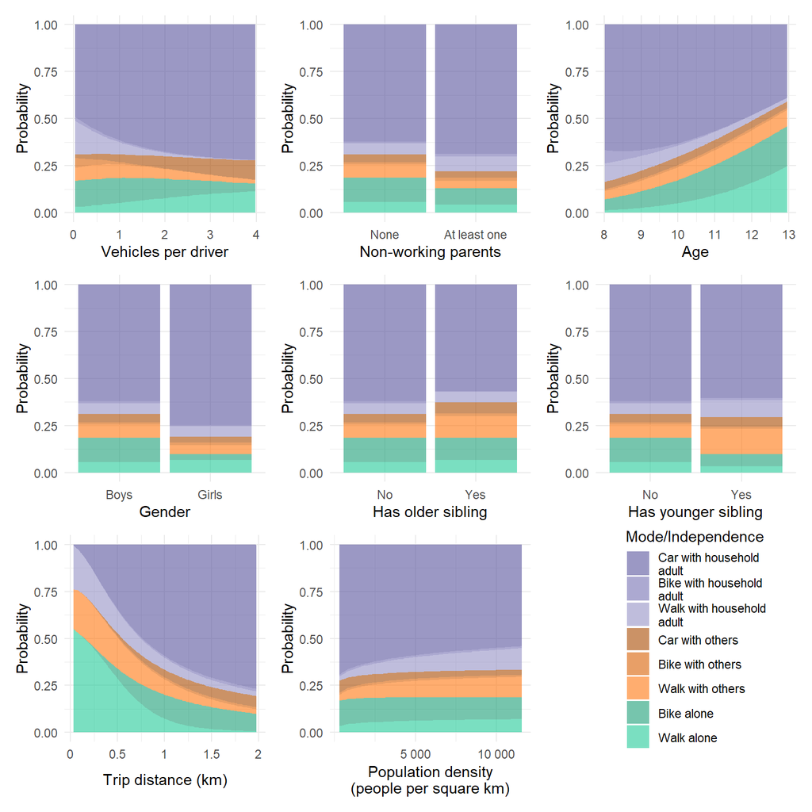

```r
veh_plot + non_work_adlt_plot + age_plot +
  female_plot + old_sib_plot + lil_sib_plot +
  dist_plot + dens_plot + guide_area() +
  plot_layout(guides = 'collect')
```

```r
ggsave(filename = "prob_plots_mode_ind.png",
       width = 6.25, height = 8, units = "in", dpi = 300)
```